# Report on study `Hanley_2001` from

# Trait measurements

## Overview

The dataset includes 55 individual data points from 11 taxa, with data included for the following 5 traits:

| trait_name | taxa | records | records_per_taxa |
| --- | --- | --- | --- |
| leaf_N_per_dry_mass | 6 | 7 | 1.17 |
| leaf_mass_per_area | 11 | 12 | 1.09 |
| leaf_phenol_per_dry_mass | 11 | 12 | 1.09 |
| leaf_thickness | 11 | 12 | 1.09 |
| serotiny | 11 | 12 | 1.09 |

**Question:** (section `traits`) Does this study include other trait data we may have missed?

**Question:** (section `traits`) It appears as though we mostly have means for each taxa. Can you provide individual-level measurements?

**Question:** (section `traits`) Were any of your data sourced from other studies? If so, can you tell us which records and the source (so that we can avoid duplicates, where possible)?

All data passed quality control so nothing was excluded in this study. (Yay!)

## Numerical traits

We have recorded the following traits with continuous numerical values in this dataset. Plots are shown comparing the distribution of values in your study (blue) to those in other datasets within AusTraits (red, green). For each trait, please eyeball the information provided and let us know of any issues or updates where appropriate.

### leaf_mass_per_area

We aligned the contributed variable called `SLA (SE) (mm2/mg)` in the data you supplied with the trait `leaf_mass_per_area` in the AusTraits database, with value_types `mean`.

The original variable was supplied with units `mm2/mg`; these were converted to our standard `g/m2`.

The data has the following properties:

- **standardised name**: leaf_mass_per_area
- **standardised description**: A leaf morphology trait [TO:0000748] which is the ratio [PATO:0001470] of the leaf dry [PATO:0001824] mass [PATO:0000125] to the leaf [PO:0025034] area [PATO:0001323], measured on an entire leaf, including the entire leaf lamina [PO:0020039] and the petiole [PO:0020038].;The ratio of leaf dry mass to leaf area, measured on an entire leaf including the petiole; LMA. (The inverse of specific leaf area, SLA.)
- **label**: Leaf mass per area
- **units**: g/m2
- **records**: 12 in this study (of 28611 in AusTraits)
- **allowable range**: 1 - 3000 g/m2
- **observed range in this study**: 64.1025641025641 - 161.290322580645 g/m2

Data for this trait in this study were collected using the following methods:

- **value_type**: mean
- **replicates**: 10
- **methods**: Cotyledon thickness was quantified using vernier callipers placed mid-way across the long axis of a single cotyledon. Cotyledon area was determined by measuring the area of a single cotyledon using an image analyser (Delta-T Devices, Cambridge). The same cotyledons were oven dried at 80?C overnight and dry weight biomass determined. SLA was calculated by dividing cotyledon area by dry weight. The process was repeated for ten individuals of each species.

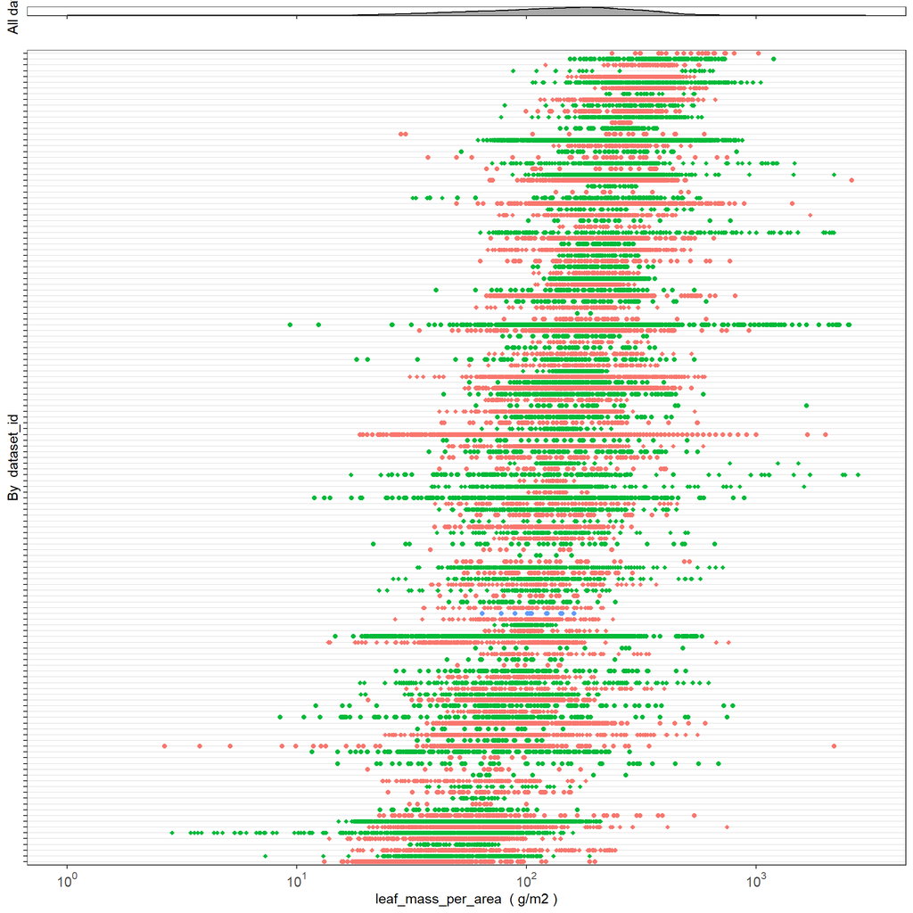

### leaf_N_per_dry_mass

We aligned the contributed variable called `% Nitrogen (SE)` in the data you supplied with the trait `leaf_N_per_dry_mass` in the AusTraits database, with value_types `mean`.

The original variable was supplied with units `%`; these were converted to our standard `mg/g`.

The data has the following properties:

- **standardised name**: leaf_N_per_dry_mass
- **standardised description**: The ratio [PATO:0001470] of the mass [PATO:0000125] of nitrogen [CHEBI:25555] in a leaf [PO:0025034] to leaf dry mass [TO:0001014].;The ratio of the mass of nitrogen in a leaf to leaf dry mass.
- **label**: Leaf nitrogen (N) content per unit leaf dry mass
- **units**: mg/g
- **records**: 7 in this study (of 11494 in AusTraits)
- **allowable range**: 0.5 - 100 mg/g
- **observed range in this study**: 52.4 - 99.6 mg/g

Data for this trait in this study were collected using the following methods:

- **value_type**: mean
- **replicates**: 10
- **methods**: Percentage leaf nitrogen was determined on a three-channel autoanalyser system, using a modified Kjeldahl digestion method (Anonymous 1977). Samples were taken from the same plants used in the phenolic test and were prepared in a similar way. About 0.1 g dried and milled shoot material was digested in a 6 ml mixture of sulphuric acid and 6% salicylic acid overnight (Ekpete and Cornfield 1964). This mixture was boiled at 350C for 20 min, allowed to cool and 2 ml hydrogen peroxide added. The process was repeated 3 times until the samples became clear, after which a final heat treatment at 350C for 30 min was applied (Yuen and Pollard 1954). Nitrogen was colorimetrically determined by indophenol blue (Searle 1984)

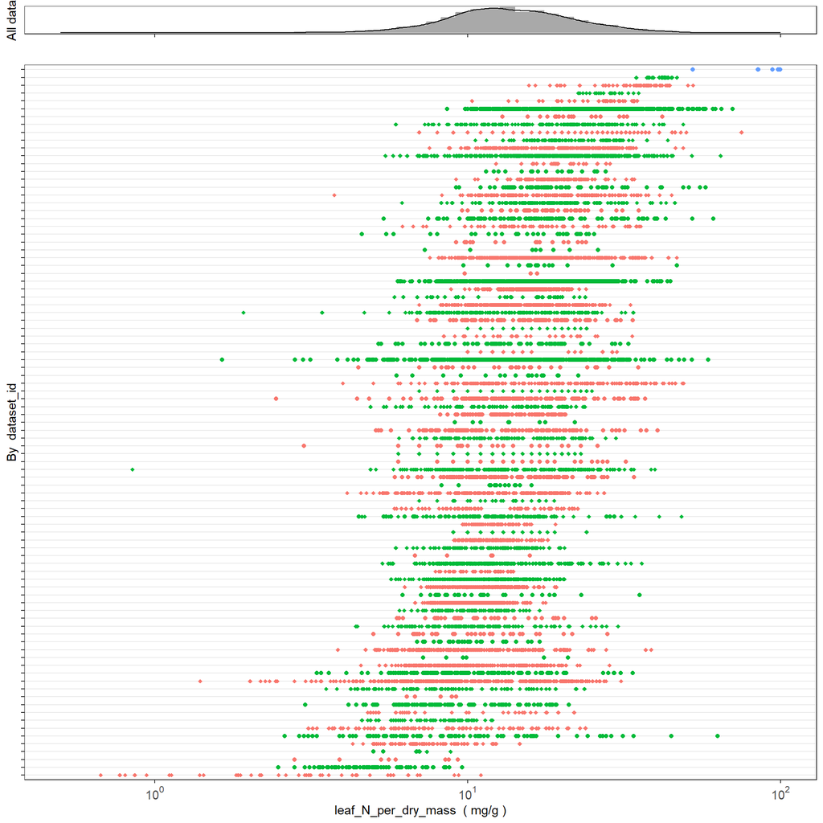

OUTLIERS: 7 of points in your dataset lie in either the bottom or top 2.5 percent of data

**Question:** (section `traits`) More than 10% of your data points for the trait `leaf_N_per_dry_mass` are outliers, does this seem reasonable, given what you know about the biology of these taxa and overall distribution of values in AusTraits?

### leaf_phenol_per_dry_mass

We aligned the contributed variable called `% Phenolics (SE)` in the data you supplied with the trait `leaf_phenol_per_dry_mass` in the AusTraits database, with value_types `mean`.

The original variable was supplied with units `%`; these were converted to our standard `mg/g`.

The data has the following properties:

- **standardised name**: leaf_phenol_per_dry_mass
- **standardised description**: The ratio [PATO:0001470] of the mass [PATO:0000125] of phenol [CHEBI:33853] in a leaf [PO:0025034] to leaf dry mass [TO:0001014], where phenol content is measured as gallic acid [CHEBI:30778] equivalents.;The ratio of the mass of phenol in a leaf to leaf dry mass, where phenol content is measured as gallic acid equivalents.
- **label**: Total leaf phenolic content per unit leaf dry mass
- **units**: mg/g
- **records**: 12 in this study (of 808 in AusTraits)
- **allowable range**: 1 - 1000 mg/g
- **observed range in this study**: 12.9 - 35.6 mg/g

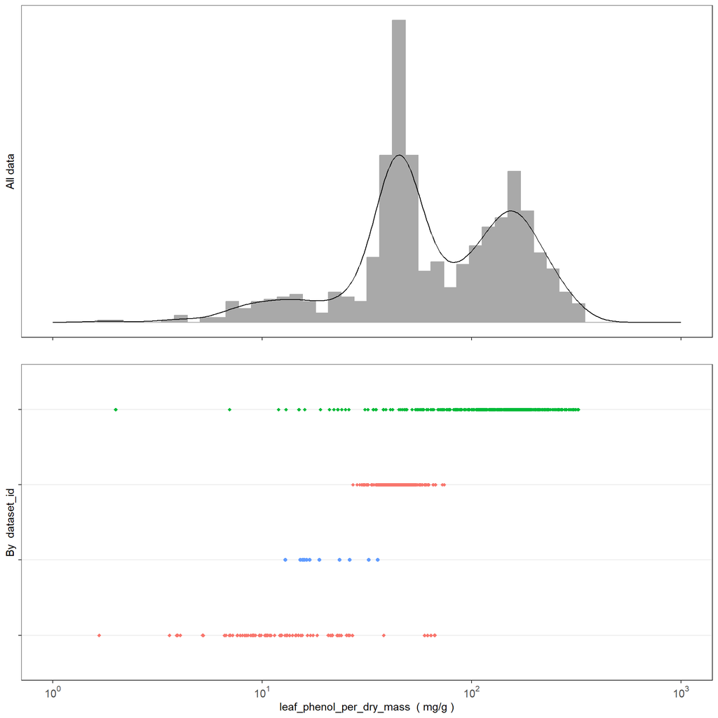

### leaf_thickness

We aligned the contributed variable called `Leaf thickness (SE) (mm)` in the data you supplied with the trait `leaf_thickness` in the AusTraits database, with value_types `mean`.

The original variable was supplied with units `mm`; these were converted to our standard `mm`.

The data has the following properties:

- **standardised name**: leaf_thickness
- **standardised description**: The thickness [PATO:0000915] of the leaf lamina [PO:0020039], measured away from the midrib [PO:0020139].;Thickness of the leaf lamina, generally measured away from the midrib.
- **label**: Leaf thickness
- **units**: mm
- **records**: 12 in this study (of 6354 in AusTraits)
- **allowable range**: 0.01 - 51 mm
- **observed range in this study**: 0.59 - 1.32 mm

Data for this trait in this study were collected using the following methods:

- **value_type**: mean
- **replicates**: 10
- **methods**: Cotyledon thickness was quantified using vernier callipers placed mid-way across the long axis of a single cotyledon. Cotyledon area was determined by measuring the area of a single cotyledon using an image analyser (Delta-T Devices, Cambridge). The same cotyledons were oven dried at 80?C overnight and dry weight biomass determined. SLA was calculated by dividing cotyledon area by dry weight. The process was repeated for ten individuals of each species.

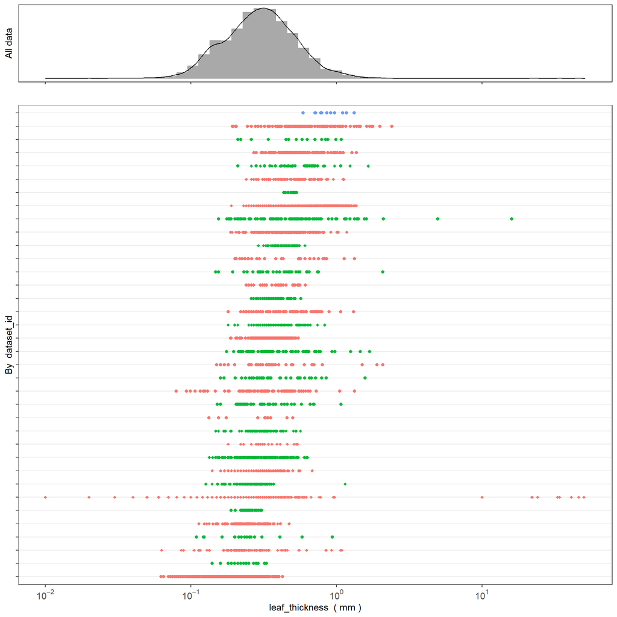

OUTLIERS: 5 of points in your dataset lie in either the bottom or top 2.5 percent of data

**Question:** (section `traits`) More than 10% of your data points for the trait `leaf_thickness` are outliers, does this seem reasonable, given what you know about the biology of these taxa and overall distribution of values in AusTraits?

## Categorical traits

We have recorded the following traits with categorical values in this dataset. Tables are shown comparing the distribution of values in your study to others in the dataset

### serotiny

We aligned the variable called `serotiny`in the data you supplied with the trait `serotiny` in the AusTraits database.

The contributed data has the following properties:

- **standardised name**: serotiny
- **standardised description**: A fire response trait which indicates whether a fruit [PO:0009001] or cone [strobilus; PO:0025083] remains closed in the canopy [ENVO:01001242] after maturation [TO:0002661], with the seed [PO:0009010] only being released [NCIT:C42882] after a specific [NCIT:C38024] environmental conditions [ENVO:01000203], usually an environmental cue associated with a fire [ENVO:01000786], but possibly also drought or extreme heat.;Categorical variable describing whether a fruit or cone remains closed in the plant canopy after maturation until an environmental cue, usually a fire, but possibly also drought or extreme heat, triggers it to release its seeds.
- **label**: Serotiny
- **records**: 12 in this study (of 1632 in AusTraits)

Data for this trait in this study were collected using the following methods:

- **value_type**: mode
- **replicates**: NA
- **methods**: Expert knowledge and field observations.

The allowable values for this trait in AusTraits are:

| trait_value | definition |
| --- | --- |
| not_serotinous | Plant does not display serotiny. |
| serotinous | Plant serotinous, level not specified. |
| serotiny_high | Plant displays a strong level of serotiny, indicating all seeds are retained as a canopy seedbank until an environmental cue triggers their release. |
| serotiny_low | Plant displays a weak level of serotiny, indicating it releases most of its seeds gradually, with only a small proportion of the seeds retained as a canopy seedbank until an environmental cue triggers… |
| serotiny_moderate | Plant displays a moderate level of serotiny, indicating it releases some of its seeds gradually, with the remainder retained as a canopy seedbank until an environmental cue triggers the release of the… |

The following substitutions have been implemented to align categorical trait values in the submitted data table with allowable trait values specified in the AusTraits traits_definitions file.

| trait_name | value in contributed data table | AusTraits aligned value |
| --- | --- | --- |
| serotiny | strong | serotiny_high |
| serotiny | weak | serotiny_low |

The following table shows distribution of recorded values in your study and AusTraits as a whole. Note that space-delimited strings of values, indicate when multiple trait values were recorded for a single `observation` (taxon or individual-level) within a single study.

| value | Counts study | Counts total | Percent % study | Percent % total |
| --- | --- | --- | --- | --- |
| serotiny_high | 6 | 34 | 50 | 2 |
| serotiny_low | 6 | 32 | 50 | 2 |
| not_serotinous | 0 | 912 | 0 | 56 |
| serotinous | 0 | 567 | 0 | 35 |
| serotiny_moderate | 0 | 79 | 0 | 5 |
| not_serotinous serotinous | 0 | 8 | 0 | 0 |

**Question:** (section `traits`) Do the data for the trait `serotiny` appear correct?

# Taxon list

We have records on the following taxa from your study. We have attempted to align taxon names in this study with the Australian Plant Census (APC) or Australian Plant Names Index (APNI).

## Full taxa list

The table below shows the table of all taxa in this study, where possible using the name aligned with the APC. Columns are as follows:

| key | value |
| --- | --- |
| taxon_name | Scientific name of the taxon on which traits were sampled, without authorship. When possible, this is the currently accepted (botanical) or valid (zoological) scientific name, but might also be a high… |
| taxonomic_dataset | Name of the taxonomy (tree) that contains this concept. ie. APC, AusMoss etc. |
| taxon_rank | The taxonomic rank of the most specific name in the scientific name. |
| trinomial | The infraspecific taxon name match for an original name. This column is assigned `na` for taxon name that are at a broader taxonomic_resolution. |
| binomial | The species-level taxon name match for an original name. This column is assigned `na` for taxon name that are at a broader taxonomic_resolution. |
| genus | Genus of the taxon without authorship. |
| family | Family of the taxon. |
| taxon_distribution | Known distribution of the taxon, by Australian state. |
| establishment_means | Statement about whether an organism or organisms have been introduced to a given place and time through the direct or indirect activity of modern humans. |
| taxonomic_status | The status of the use of the scientificName as a label for the taxon in regard to the ‘accepted (or valid) taxonomy’. The assigned taxonomic status must be linked to a specific taxonomic reference tha… |
| taxon_id | An identifier for the set of taxon information (data associated with the taxon class). May be a global unique identifier or an identifier specific to the data set. Must be resolvable within this datas… |
| taxon_id_genus | An identifier for the set of taxon information (data associated with the taxon class) for the genus associated with a taxon name. May be a global unique identifier or an identifier specific to the dat… |
| taxon_id_family | An identifier for the set of taxon information (data associated with the taxon class) for the family associated with a taxon name. May be a global unique identifier or an identifier specific to the da… |
| scientific_name | The full scientific name, with authorship and date information if known. |
| scientific_name_id | An identifier for the set of taxon information (data associated with the taxon class). May be a global unique identifier or an identifier specific to the data set. Must be resolvable within this datas… |

Clicking on the name will take you to the relevant taxonomic record in the APC or APNI, where known:

| taxon_name | taxonomic_dataset | taxon_rank | trinomial | binomial | genus | family | taxon_distribution | establishment_means | taxonomic_status | taxon_id | taxon_id_genus | taxon_id_family | scientific_name | scientific_name_id |
| --- | --- | --- | --- | --- | --- | --- | --- | --- | --- | --- | --- | --- | --- | --- |
| [Banksia baxteri](https://id.biodiversity.org.au/node/apni/2908864) | APC | species |  | Banksia baxteri | Banksia | Proteaceae | WA | native | accepted | https://id.biodiversity.org.au/node/apni/2908864 | https://id.biodiversity.org.au/taxon/apni/51732900 | https://id.biodiversity.org.au/taxon/apni/51732901 | Banksia baxteri R.Br. | https://id.biodiversity.org.au/name/apni/106589 |
| [Banksia carlinoides](https://id.biodiversity.org.au/node/apni/2897780) | APC | species |  | Banksia carlinoides | Banksia | Proteaceae | WA | native | accepted | https://id.biodiversity.org.au/node/apni/2897780 | https://id.biodiversity.org.au/taxon/apni/51732900 | https://id.biodiversity.org.au/taxon/apni/51732901 | Banksia carlinoides (Meisn.) A.R.Mast & K.R.Thiele | https://id.biodiversity.org.au/name/apni/205090 |
| [Banksia coccinea](https://id.biodiversity.org.au/node/apni/2898124) | APC | species |  | Banksia coccinea | Banksia | Proteaceae | WA | native | accepted | https://id.biodiversity.org.au/node/apni/2898124 | https://id.biodiversity.org.au/taxon/apni/51732900 | https://id.biodiversity.org.au/taxon/apni/51732901 | Banksia coccinea R.Br. | https://id.biodiversity.org.au/name/apni/106776 |
| [Banksia leptophylla](https://id.biodiversity.org.au/node/apni/2905696) | APC | species |  | Banksia leptophylla | Banksia | Proteaceae | WA | native | accepted | https://id.biodiversity.org.au/node/apni/2905696 | https://id.biodiversity.org.au/taxon/apni/51732900 | https://id.biodiversity.org.au/taxon/apni/51732901 | Banksia leptophylla A.S.George | https://id.biodiversity.org.au/name/apni/107830 |
| [Banksia mucronulata](https://id.biodiversity.org.au/taxon/apni/51445265) | APC | species |  | Banksia mucronulata | Banksia | Proteaceae | WA | native | accepted | https://id.biodiversity.org.au/taxon/apni/51445265 | https://id.biodiversity.org.au/taxon/apni/51732900 | https://id.biodiversity.org.au/taxon/apni/51732901 | Banksia mucronulata (R.Br.) A.R.Mast & K.R.Thiele | https://id.biodiversity.org.au/name/apni/205140 |
| [Banksia prionotes](https://id.biodiversity.org.au/node/apni/2905345) | APC | species |  | Banksia prionotes | Banksia | Proteaceae | WA | native | accepted | https://id.biodiversity.org.au/node/apni/2905345 | https://id.biodiversity.org.au/taxon/apni/51732900 | https://id.biodiversity.org.au/taxon/apni/51732901 | Banksia prionotes Lindl. | https://id.biodiversity.org.au/name/apni/108720 |
| [Banksia sessilis](https://id.biodiversity.org.au/taxon/apni/51445303) | APC | species |  | Banksia sessilis | Banksia | Proteaceae | WA | native | accepted | https://id.biodiversity.org.au/taxon/apni/51445303 | https://id.biodiversity.org.au/taxon/apni/51732900 | https://id.biodiversity.org.au/taxon/apni/51732901 | Banksia sessilis (Knight) A.R.Mast & K.R.Thiele | https://id.biodiversity.org.au/name/apni/205181 |
| [Hakea cucullata](https://id.biodiversity.org.au/node/apni/2886867) | APC | species |  | Hakea cucullata | Hakea | Proteaceae | WA, SA (naturalised) | native and naturalised | accepted | https://id.biodiversity.org.au/node/apni/2886867 | https://id.biodiversity.org.au/taxon/apni/51445456 | https://id.biodiversity.org.au/taxon/apni/51732901 | Hakea cucullata R.Br. | https://id.biodiversity.org.au/name/apni/93169 |
| [Hakea lasiantha](https://id.biodiversity.org.au/node/apni/2916479) | APC | species |  | Hakea lasiantha | Hakea | Proteaceae | WA | native | accepted | https://id.biodiversity.org.au/node/apni/2916479 | https://id.biodiversity.org.au/taxon/apni/51445456 | https://id.biodiversity.org.au/taxon/apni/51732901 | Hakea lasiantha R.Br. | https://id.biodiversity.org.au/name/apni/84904 |
| [Hakea psilorrhyncha](https://id.biodiversity.org.au/node/apni/2904960) | APC | species |  | Hakea psilorrhyncha | Hakea | Proteaceae | WA | native | accepted | https://id.biodiversity.org.au/node/apni/2904960 | https://id.biodiversity.org.au/taxon/apni/51445456 | https://id.biodiversity.org.au/taxon/apni/51732901 | Hakea psilorrhyncha R.M.Barker | https://id.biodiversity.org.au/name/apni/117761 |
| [Hakea trifurcata](https://id.biodiversity.org.au/node/apni/2891077) | APC | species |  | Hakea trifurcata | Hakea | Proteaceae | WA | native | accepted | https://id.biodiversity.org.au/node/apni/2891077 | https://id.biodiversity.org.au/taxon/apni/51445456 | https://id.biodiversity.org.au/taxon/apni/51732901 | Hakea trifurcata (Sm.) R.Br. | https://id.biodiversity.org.au/name/apni/56682 |

To create the list of aligned taxa, we needed to make some taxonomic changes. This involved two stages.

- **Stage 1**: Where possible (i.e. there was no or only a few characters difference), the name you supplied was matched automatically with a known name in APC or APNI. In other cases we may have aligned the taxa by searching for an appropriate match. Such changes are documented in the study metadata file. The variable `aligned_name` shows the updated name. The variable `d1` shows the number of characters difference between the `original_name` and `aligned_name`.
- **Stage 2**: Once aligned with a known name, we used the APC to update the `aligned_name` to an accepted name. The taxonomic status of the aligned name is indicated in column `status aligned name`. If accepted, no change was made. If it is a synonym or otherwise, the name was changed according to the recommendation given in the APC. Where they existed, we preferred to take the accepted status of an `aligned_name`, if it existed. Alternative status values are indicated in brackets. This indicate if alternative uses of the name were ever applied.

Links on `aligned_name` and `taxon_name` take you to the APC or APNI record for that name.

| original_name | d1 | aligned_name | d2 | taxon_name | aligned_name_taxonomic_status |
| --- | --- | --- | --- | --- | --- |
| Dryandra carlinodes | 1 | [Dryandra carlinoides](https://id.biodiversity.org.au/instance/apni/861995) | 6 | [Banksia carlinoides](https://id.biodiversity.org.au/node/apni/2897780) | nomenclatural synonym |
| Dryandra mucronulata |  | [Dryandra mucronulata](https://id.biodiversity.org.au/instance/apni/51445259) | 6 | [Banksia mucronulata](https://id.biodiversity.org.au/taxon/apni/51445265) | nomenclatural synonym |
| Dryandra sessilis |  | [Dryandra sessilis](https://id.biodiversity.org.au/instance/apni/863365) | 6 | [Banksia sessilis](https://id.biodiversity.org.au/taxon/apni/51445303) | nomenclatural synonym |
| Hakea lasianrha | 1 | [Hakea lasiantha](https://id.biodiversity.org.au/node/apni/2916479) |  | [Hakea lasiantha](https://id.biodiversity.org.au/node/apni/2916479) | accepted |
| Hakea psilorryncha | 1 | [Hakea psilorrhyncha](https://id.biodiversity.org.au/node/apni/2904960) |  | [Hakea psilorrhyncha](https://id.biodiversity.org.au/node/apni/2904960) | accepted |
| Hakea trifurcara | 1 | [Hakea trifurcata](https://id.biodiversity.org.au/node/apni/2891077) |  | [Hakea trifurcata](https://id.biodiversity.org.au/node/apni/2891077) | accepted |

## Unknown taxa

We were unable to find taxonomic matches for the following taxa in the data. Where genus and family are shown, the specified genus aligns with an accepted genus. The term `unplaced` appears as the `status` for names on the APNI list, but not yet reviewed by the APC.

| taxon_name | taxonomic_dataset | taxon_rank | trinomial | binomial | genus | family | taxonomic_status | taxon_id_genus | taxon_id_family | scientific_name |
| --- | --- | --- | --- | --- | --- | --- | --- | --- | --- | --- |

**Question:** (section `taxonomic_updates`) Do these taxonomic alignments and corrections look reasonable?

# Review of questions

Here is a summary of the questions we would like answers to. Clicking on the links will take you back to the appropriate spot in the document. Please copy and past these into an email when you respond.

1. (section `people`) Are all appropriate people listed, with appropriate details? link
2. (section `source`) Are the citation details for this study correct? link
3. (section `dataset`) Can you provide more detailed information for any of these variables? link
4. (section `locations`) Do site details look complete and accurate? As a minimum we would like `latitude`, `longitude`, `description`. link
5. (section `locations`) Do the additional site details look complete? link
6. (section `traits`) Does this study include other trait data we may have missed? link
7. (section `traits`) It appears as though we mostly have means for each taxa. Can you provide individual-level measurements? link
8. (section `traits`) Were any of your data sourced from other studies? If so, can you tell us which records and the source (so that we can avoid duplicates, where possible)? link
9. (section `traits`) More than 10% of your data points for the trait `leaf_N_per_dry_mass` are outliers, does this seem reasonable, given what you know about the biology of these taxa and overall distribution of values in AusTraits? link
10. (section `traits`) More than 10% of your data points for the trait `leaf_thickness` are outliers, does this seem reasonable, given what you know about the biology of these taxa and overall distribution of values in AusTraits? link
11. (section `traits`) Do the data for the trait `serotiny` appear correct? link
12. (section `taxonomic_updates`) Do these taxonomic alignments and corrections look reasonable? link

# Session information

The technical information below may useful for us for the sake of reproducibility, but you don’t need to worry about it!

This report was generated using the data from the commit 2abde0e97c3a07e658adc40f3f13a0bea6e058dc